# **Team:** Kerui Geng (Graduate)

# **Project:** Predicting comsumers' other buying behavior using their existing purchasing information

# **Github link**:https://github.com/keruigeng/keruigeng.github.io.git

## **Project Goals**

The team intends to predict the consumers' other buying behavior based on their one-time purchasing information. In economics, some products are complementary, which means that consumer gains more utilities if they consume the two products together. However, whether the products are complementary or not is largely degermed by consumers’ preference. Through consumer’s purchasing behavior, their preference can be revealed. If we know more about consumers’ preference, we can recommend the corresponding product to them. This is an efficient way to promote selling.

## **Collaboration Plan**

I am the only number of this team, responsible for all the work. However, updating regularly is essential for project improvement. I plan to work on this project every week. This is a hard project containing some machining learning algorithm and natural language processing. I plan to talk with professor or TA after processing the raw data. Accoding to their feedbacks, I will update some main results.

```python
from google.colab import drive
drive.mount('/content/drive')
```

```python
import pandas as pd
import numpy as np
import matplotlib.pyplot as plt
```

## Extraction, Transform, and Load (ETL)

```python
df=pd.read_csv('/content/amazon_co_ecommerce_sample.csv')
```

```python
df.head()
```

|  | uniq_id | product_name | manufacturer | price | number_available_in_stock | number_of_reviews | number_of_answered_questions | average_review_rating | amazon_category_and_sub_category | customers_who_bought_this_item_also_bought | description | product_information | product_description | items_customers_buy_after_viewing_this_item | customer_questions_and_answers | customer_reviews | sellers |
| --- | --- | --- | --- | --- | --- | --- | --- | --- | --- | --- | --- | --- | --- | --- | --- | --- | --- |
| 0 | eac7efa5dbd3d667f26eb3d3ab504464 | Hornby 2014 Catalogue | Hornby | £3.42 | 5 new | 15.0 | 1.0 | 4.9 out of 5 stars | Hobbies > Model Trains & Railway Sets > Rail V... | http://www.amazon.co.uk/Hornby-R8150-Catalogue... | Product Description Hornby 2014 Catalogue Box ... | Technical Details Item Weight640 g Product Dim... | Product Description Hornby 2014 Catalogue Box ... | http://www.amazon.co.uk/Hornby-R8150-Catalogue... | Does this catalogue detail all the previous Ho... | Worth Buying For The Pictures Alone (As Ever) ... | {"seller"=>[{"Seller_name_1"=>"Amazon.co.uk", ... |
| 1 | b17540ef7e86e461d37f3ae58b7b72ac | FunkyBuys® Large Christmas Holiday Express Fes... | FunkyBuys | £16.99 | NaN | 2.0 | 1.0 | 4.5 out of 5 stars | Hobbies > Model Trains & Railway Sets > Rail V... | http://www.amazon.co.uk/Christmas-Holiday-Expr... | Size Name:Large FunkyBuys® Large Christmas Hol... | Technical Details Manufacturer recommended age... | Size Name:Large FunkyBuys® Large Christmas Hol... | http://www.amazon.co.uk/Christmas-Holiday-Expr... | can you turn off sounds // hi no you cant turn... | Four Stars // 4.0 // 18 Dec. 2015 // By\n \... | {"seller"=>{"Seller_name_1"=>"UHD WHOLESALE", ... |
| 2 | 348f344247b0c1a935b1223072ef9d8a | CLASSIC TOY TRAIN SET TRACK CARRIAGES LIGHT EN... | ccf | £9.99 | 2 new | 17.0 | 2.0 | 3.9 out of 5 stars | Hobbies > Model Trains & Railway Sets > Rail V... | http://www.amazon.co.uk/Classic-Train-Lights-B... | BIG CLASSIC TOY TRAIN SET TRACK CARRIAGE LIGHT... | Technical Details Manufacturer recommended age... | BIG CLASSIC TOY TRAIN SET TRACK CARRIAGE LIGHT... | http://www.amazon.co.uk/Train-With-Tracks-Batt... | What is the gauge of the track // Hi Paul.Trut... | **Highly Recommended!** // 5.0 // 26 May 2015 ... | {"seller"=>[{"Seller_name_1"=>"DEAL-BOX", "Sel... |
| 3 | e12b92dbb8eaee78b22965d2a9bbbd9f | HORNBY Coach R4410A BR Hawksworth Corridor 3rd | Hornby | £39.99 | NaN | 1.0 | 2.0 | 5.0 out of 5 stars | Hobbies > Model Trains & Railway Sets > Rail V... | NaN | Hornby 00 Gauge BR Hawksworth 3rd Class W 2107... | Technical Details Item Weight259 g Product Dim... | Hornby 00 Gauge BR Hawksworth 3rd Class W 2107... | NaN | NaN | I love it // 5.0 // 22 July 2013 // By\n \n... | NaN |
| 4 | e33a9adeed5f36840ccc227db4682a36 | Hornby 00 Gauge 0-4-0 Gildenlow Salt Co. Steam... | Hornby | £32.19 | NaN | 3.0 | 2.0 | 4.7 out of 5 stars | Hobbies > Model Trains & Railway Sets > Rail V... | http://www.amazon.co.uk/Hornby-R6367-RailRoad-... | Product Description Hornby RailRoad 0-4-0 Gild... | Technical Details Item Weight159 g Product Dim... | Product Description Hornby RailRoad 0-4-0 Gild... | http://www.amazon.co.uk/Hornby-R2672-RailRoad-... | NaN | Birthday present // 5.0 // 14 April 2014 // By... | NaN |

```python
df.info()
```

```
<class 'pandas.core.frame.DataFrame'>
RangeIndex: 10000 entries, 0 to 9999
Data columns (total 17 columns):
 #   Column                                       Non-Null Count  Dtype
---  ------                                       --------------  -----
 0   uniq_id                                      10000 non-null  object
 1   product_name                                 10000 non-null  object
 2   manufacturer                                 9993 non-null   object
 3   price                                        8565 non-null   object
 4   number_available_in_stock                    7500 non-null   object
 5   number_of_reviews                            9982 non-null   float64
 6   number_of_answered_questions                 9235 non-null   float64
 7   average_review_rating                        9982 non-null   object
 8   amazon_category_and_sub_category             9310 non-null   object
 9   customers_who_bought_this_item_also_bought   8938 non-null   object
 10  description                                  9349 non-null   object
 11  product_information                          9942 non-null   object
 12  product_description                          9349 non-null   object
 13  items_customers_buy_after_viewing_this_item  6935 non-null   object
 14  customer_questions_and_answers               914 non-null    object
 15  customer_reviews                             9979 non-null   object
 16  sellers                                      6918 non-null   object
dtypes: float64(2), object(15)
memory usage: 1.3+ MB
```

The original data are primarily object(strings). I need obtain some numerical information based on this raw data.

```python
product=df.copy()
```

Variables, "price" and "number_available_in_stock", are string. I need the numerical element of those varibale.

```python
product['price']=pd.to_numeric(df['price'].str.replace('£',''),errors='coerce')
product['price']
```

```
0        3.42
1       16.99
2        9.99
3       39.99
4       32.19
        ...
9995    22.95
9996    39.99
9997    43.99
9998    49.81
9999    21.20
Name: price, Length: 10000, dtype: float64
```

```python
df['number_available_in_stock']=df.number_available_in_stock.str.replace('new','')
df['number_available_in_stock']=df.number_available_in_stock.str.replace('used','')
```

```python
product['number_available_in_stock']=pd.to_numeric(df['number_available_in_stock'].str.strip(),errors='coerce')
product['number_available_in_stock']
```

```
0        5.0
1        NaN
2        2.0
3        NaN
4        NaN
        ...
9995     5.0
9996     NaN
9997     3.0
9998     3.0
9999    31.0
Name: number_available_in_stock, Length: 10000, dtype: float64
```

```python
product['average_review_rating']=pd.to_numeric(df.average_review_rating.str.replace('out of 5 stars','').str.strip())
product['average_review_rating']
```

```
0       4.9
1       4.5
2       3.9
3       5.0
4       4.7
       ...
9995    5.0
9996    4.0
9997    5.0
9998    5.0
9999    4.5
Name: average_review_rating, Length: 10000, dtype: float64
```

```python
product[['category','sub_category_1','sub_category_2','sub_category_3','sub_category_4']]=df.amazon_category_and_sub_category.str.split('>', expand=True)
product[['category','sub_category_1','sub_category_2','sub_category_3','sub_category_4']]
```

|  | category | sub_category_1 | sub_category_2 | sub_category_3 | sub_category_4 |
| --- | --- | --- | --- | --- | --- |
| 0 | Hobbies | Model Trains & Railway Sets | Rail Vehicles | Trains | None |
| 1 | Hobbies | Model Trains & Railway Sets | Rail Vehicles | Trains | None |
| 2 | Hobbies | Model Trains & Railway Sets | Rail Vehicles | Trains | None |
| 3 | Hobbies | Model Trains & Railway Sets | Rail Vehicles | Trains | None |
| 4 | Hobbies | Model Trains & Railway Sets | Rail Vehicles | Trains | None |
| ... | ... | ... | ... | ... | ... |
| 9995 | Hobbies | Collectible Figures & Memorabilia | Collectible Props & Memorabilia | None | None |
| 9996 | Characters & Brands | Star Wars | Toys | None | None |
| 9997 | Novelty & Special Use | Novelty | Accessories | Buttons & Pins | None |
| 9998 | Hobbies | Collectible Figures & Memorabilia | Collectible Props & Memorabilia | None | None |
| 9999 | Characters & Brands | Star Wars | Toys | None | None |

10000 rows × 5 columns

"customers_who_bought_this_item_also_bought" is the label I am interested in. It indicates the information about items this consumer bought after buying the exsting product. From the web site (http://www.amazon..), I can get the number of items the consumer bought after buying this product. The same is true for varible "items_customers_buy_after_viewing_this_item"

```python
product['num_items_customers_who_bought_this_item_also_bought']=df.customers_who_bought_this_item_also_bought.str.count('http://www.amazon').fillna(0)
product['num_items_customers_buy_after_viewing_this_item']=df.items_customers_buy_after_viewing_this_item.str.count('http://www.amazon').fillna(0)
```

```python
###The data--product now is tidy, and suitful for prediction
product.head()
```

|  | uniq_id | product_name | manufacturer | price | number_available_in_stock | number_of_reviews | number_of_answered_questions | average_review_rating | amazon_category_and_sub_category | customers_who_bought_this_item_also_bought | ... | customer_questions_and_answers | customer_reviews | sellers | category | sub_category_1 | sub_category_2 | sub_category_3 | sub_category_4 | num_items_customers_who_bought_this_item_also_bought | num_items_customers_buy_after_viewing_this_item |
| --- | --- | --- | --- | --- | --- | --- | --- | --- | --- | --- | --- | --- | --- | --- | --- | --- | --- | --- | --- | --- | --- |
| 0 | eac7efa5dbd3d667f26eb3d3ab504464 | Hornby 2014 Catalogue | Hornby | 3.42 | 5.0 | 15.0 | 1.0 | 4.9 | Hobbies > Model Trains & Railway Sets > Rail V... | http://www.amazon.co.uk/Hornby-R8150-Catalogue... | ... | Does this catalogue detail all the previous Ho... | Worth Buying For The Pictures Alone (As Ever) ... | {"seller"=>[{"Seller_name_1"=>"Amazon.co.uk", ... | Hobbies | Model Trains & Railway Sets | Rail Vehicles | Trains | None | 6.0 | 4.0 |
| 1 | b17540ef7e86e461d37f3ae58b7b72ac | FunkyBuys® Large Christmas Holiday Express Fes... | FunkyBuys | 16.99 | NaN | 2.0 | 1.0 | 4.5 | Hobbies > Model Trains & Railway Sets > Rail V... | http://www.amazon.co.uk/Christmas-Holiday-Expr... | ... | can you turn off sounds // hi no you cant turn... | Four Stars // 4.0 // 18 Dec. 2015 // By\n \... | {"seller"=>{"Seller_name_1"=>"UHD WHOLESALE", ... | Hobbies | Model Trains & Railway Sets | Rail Vehicles | Trains | None | 6.0 | 4.0 |
| 2 | 348f344247b0c1a935b1223072ef9d8a | CLASSIC TOY TRAIN SET TRACK CARRIAGES LIGHT EN... | ccf | 9.99 | 2.0 | 17.0 | 2.0 | 3.9 | Hobbies > Model Trains & Railway Sets > Rail V... | http://www.amazon.co.uk/Classic-Train-Lights-B... | ... | What is the gauge of the track // Hi Paul.Trut... | **Highly Recommended!** // 5.0 // 26 May 2015 ... | {"seller"=>[{"Seller_name_1"=>"DEAL-BOX", "Sel... | Hobbies | Model Trains & Railway Sets | Rail Vehicles | Trains | None | 6.0 | 4.0 |
| 3 | e12b92dbb8eaee78b22965d2a9bbbd9f | HORNBY Coach R4410A BR Hawksworth Corridor 3rd | Hornby | 39.99 | NaN | 1.0 | 2.0 | 5.0 | Hobbies > Model Trains & Railway Sets > Rail V... | NaN | ... | NaN | I love it // 5.0 // 22 July 2013 // By\n \n... | NaN | Hobbies | Model Trains & Railway Sets | Rail Vehicles | Trains | None | 0.0 | 0.0 |
| 4 | e33a9adeed5f36840ccc227db4682a36 | Hornby 00 Gauge 0-4-0 Gildenlow Salt Co. Steam... | Hornby | 32.19 | NaN | 3.0 | 2.0 | 4.7 | Hobbies > Model Trains & Railway Sets > Rail V... | http://www.amazon.co.uk/Hornby-R6367-RailRoad-... | ... | NaN | Birthday present // 5.0 // 14 April 2014 // By... | NaN | Hobbies | Model Trains & Railway Sets | Rail Vehicles | Trains | None | 6.0 | 4.0 |

5 rows × 24 columns

# **Exploratory Data Analysis (EDA)**

```python
##Look the basic information of numerical variable:range, mean and counts. Pay attention to extreme values. They might make no sense
product.describe()
```

|  | price | number_available_in_stock | number_of_reviews | number_of_answered_questions | average_review_rating | num_items_customers_who_bought_this_item_also_bought | num_items_customers_buy_after_viewing_this_item |
| --- | --- | --- | --- | --- | --- | --- | --- |
| count | 8546.000000 | 7485.000000 | 9982.000000 | 9235.000000 | 9982.000000 | 10000.000000 | 10000.000000 |
| mean | 19.968272 | 7.930661 | 9.139952 | 1.834976 | 4.707283 | 4.877700 | 2.451000 |
| std | 38.210299 | 8.809243 | 33.728145 | 2.517268 | 0.372279 | 2.129882 | 1.814477 |
| min | 0.010000 | 1.000000 | 1.000000 | 1.000000 | 2.300000 | 0.000000 | 0.000000 |
| 25% | 4.990000 | 3.000000 | 1.000000 | 1.000000 | 4.500000 | 5.000000 | 0.000000 |
| 50% | 10.560000 | 5.000000 | 2.000000 | 1.000000 | 5.000000 | 6.000000 | 4.000000 |
| 75% | 19.990000 | 10.000000 | 6.000000 | 2.000000 | 5.000000 | 6.000000 | 4.000000 |
| max | 995.110000 | 92.000000 | 1399.000000 | 39.000000 | 5.000000 | 12.000000 | 4.000000 |

```
array([[<matplotlib.axes._subplots.AxesSubplot object at 0x7fecf64c6dd0>,
      dtype=object)
```

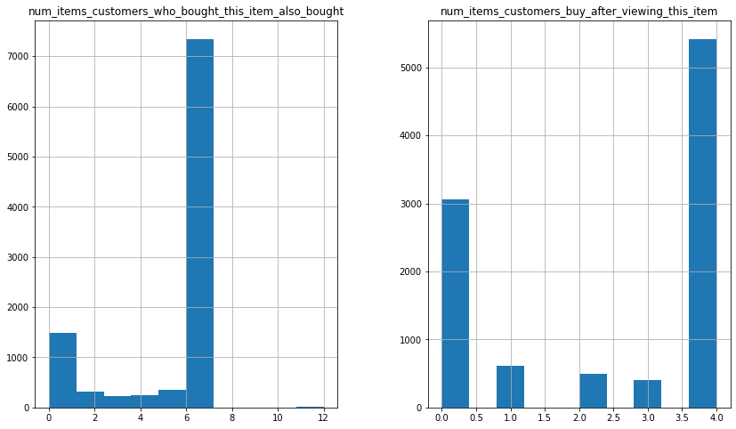

```python
##look the distribution of the outcome variables I am interested in.
product[['num_items_customers_who_bought_this_item_also_bought','num_items_customers_buy_after_viewing_this_item']].hist(figsize=(14,8))
## Even though not distributed symmetrically, they only have several values and the range is samll. So I don't think the skewness here affects my prediction.
```

```python
##check the correlation of outcome variable and item features to see their raw linear relationship
product.corr()[['num_items_customers_who_bought_this_item_also_bought','num_items_customers_buy_after_viewing_this_item']]
```

|  | num_items_customers_who_bought_this_item_also_bought | num_items_customers_buy_after_viewing_this_item |
| --- | --- | --- |
| price | -0.052883 | -0.077482 |
| number_available_in_stock | 0.169192 | 0.140321 |
| number_of_reviews | 0.113311 | 0.084969 |
| number_of_answered_questions | 0.026870 | -0.005187 |
| average_review_rating | -0.131053 | -0.121568 |
| num_items_customers_who_bought_this_item_also_bought | 1.000000 | 0.536835 |
| num_items_customers_buy_after_viewing_this_item | 0.536835 | 1.000000 |

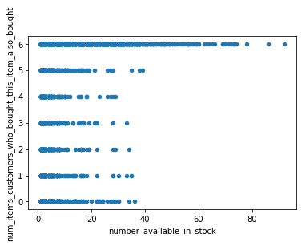

```python
product.plot.scatter("number_available_in_stock","num_items_customers_who_bought_this_item_also_bought")
```

It seems like the relationship between "number_available_in_stock" and "num_items_customers_who_bought_this_item_also_bought" is not linear. I might adopt some non-linear machine leanring algorithem.

```python
%%shell
jupyter nbconvert --to html /DSproject.ipynb
```

```
[NbConvertApp] Converting notebook /DSproject.ipynb to html
[NbConvertApp] Writing 367560 bytes to /DSproject.html
```